# Logic and Scientific Thinking

Midterm Review

Bogdan G. Popescu

bgpopescu@tec.mx

Tecnologico de Monterrey

## Exam Format

- Closed book, individual, in class.
- Covers **Sessions 1–7**.
- Tests the concepts, the vocabulary, and their application to short cases.
- The **required readings** for those sessions are examinable.

## Grading

| Component | Weight |
| --- | --- |
| Midterm exam | **30%** |
| Final exam | **30%** |
| Reading | 20% |
| Attendance | 10% |
| Participation | 10% |

Two exams, **60%** together — and neither one is cumulative.

**Reading 20%** — tested on the exams. **Attendance and participation 20%** — earned in the room.

# Part 1: The Whole Toolkit

## Finding the Argument

An **argument** gives reasons for a claim.

| **Conclusion** | the claim being defended |
| --- | --- |
| **Premises** | the reasons offered for it |

Find the conclusion **first.** Everything else is premises or noise.

## Not Everything Argues

|  | Example | Why it isn’t an argument |
| --- | --- | --- |
| **Description** | *“It’s raining outside.”* | states a fact, defends nothing |
| **Opinion** | *“Messi is the best ever.”* | a judgement, no reasons attached |
| **Contradiction** | *“No, it isn’t.”* | denies the claim, gives no reason |
| **Explanation** | *“I was late — heavy traffic.”* | says *why* an agreed fact happened |

A contradiction is one word away from an argument: **because.**

**The test for explanations:** is the conclusion actually in dispute?

## Standard Form

> “We should not cut the military budget — our Navy is smaller than in 1917.”

| P1. | Our Navy is smaller than in 1917. |
| --- | --- |
| P2. | *(hidden)* Fewer ships means a weaker military. |
| P3. | *(hidden)* Cutting the budget would shrink the fleet further. |
| P4. | *(hidden)* We should not weaken the military. |
| C. | We should not cut the military budget. |

## Three Kinds of Claim

**One question sorts them: *what would settle this?***

|  | The answer | Example |
| --- | --- | --- |
| **Empirical** | go and look | “Our Navy is smaller than in 1917.” |
| **Conceptual** | agree what the word means | “‘Strength’ means what a military can do.” |
| **Normative** | argue about what matters | “We should not weaken the military.” |

A claim packed with facts can still be **normative.** Look for the value word.

## The Hidden Ought

You cannot get a **should** out of premises that only say **is.**

- Every normative conclusion needs at least one normative premise.
- If you can’t find one stated — it is hidden.
- Naming it is how you find where to disagree.

## Guarantee or Good Bet

```
%%{init: {"flowchart": {"useMaxWidth": true, "htmlLabels": false, "nodeSpacing": 24, "rankSpacing": 34, "padding": 18}, "themeVariables": {"fontSize": "14px", "edgeLabelBackground": "#ffffff"}}}%%
flowchart TB
  A["AN ARGUMENT<br/>what does it promise?"]
  A -->|"a GUARANTEE"| D["DEDUCTIVE"]
  A -->|"a GOOD BET"| I["INDUCTIVE"]
  D --> D1["the link<br/>VALID or INVALID"]
  I --> I1["the link<br/>STRONG or WEAK"]
  D1 --> D2["+ true premises<br/>= SOUND"]
  I1 --> I2["+ true premises<br/>= COGENT"]
  style A fill:#1e293b,color:#f9fafb,stroke:#1e293b
  style D fill:#4a7c6f,color:#f9fafb,stroke:#4a7c6f
  style I fill:#b44527,color:#f9fafb,stroke:#b44527
  style D1 fill:#cfe0d8,color:#1e293b,stroke:#4a7c6f
  style D2 fill:#cfe0d8,color:#1e293b,stroke:#4a7c6f
  style I1 fill:#f4e4dc,color:#1e293b,stroke:#b44527
  style I2 fill:#f4e4dc,color:#1e293b,stroke:#b44527
```

## The Four Steps

Every argument, in the same order:

1. **Deductive or inductive?** *(a guarantee, or a good bet?)*
2. **Does the link hold?** *(deductive → valid? · inductive → strong?)*
3. **Are the premises true?**
4. **One-word verdict:** *sound · cogent · or neither.*

Step 1 decides which test steps 2 and 3 run.

## Validity Is Not Truth

**Truth values tell you almost nothing about validity.**

| Premises | Conclusion | What you can conclude |
| --- | --- | --- |
| false | either | nothing — could be valid, could be invalid |
| true | true | nothing — could be valid, could be invalid |
| **true** | **false** | **invalid — guaranteed** |

*“All cats are reptiles; all reptiles speak French; so all cats speak French.”* — **hypothetical syllogism**

Every line false — and perfectly **valid.**

## The Five Shapes

One rule, five moves: *“If it rains, the street gets wet.”*

|  | The move |  |
| --- | --- | --- |
| **Modus ponens** | It rained → **street is wet** | valid |
| **Modus tollens** | Street is dry → **it didn’t rain** | valid |
| **Hypothetical syllogism** | rain → wet → **slippery** | valid |
| **Affirming the consequent** | Street is wet → **it rained** | **trap** |
| **Denying the antecedent** | It didn’t rain → **street is dry** | **trap** |

Both traps forget the **burst pipe** — the street can be wet without rain.

## Modus Ponens

**P1:** If something is a dog, then it is a mammal.  
**P2:** Fido is a dog.  
**C:** Fido is a mammal.

**modus ponens**

Shape: **If P, then Q. P. so Q**

**Valid** — the *if* is met, so the *then* follows.

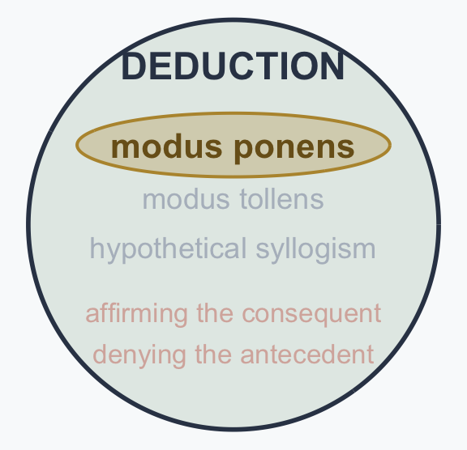

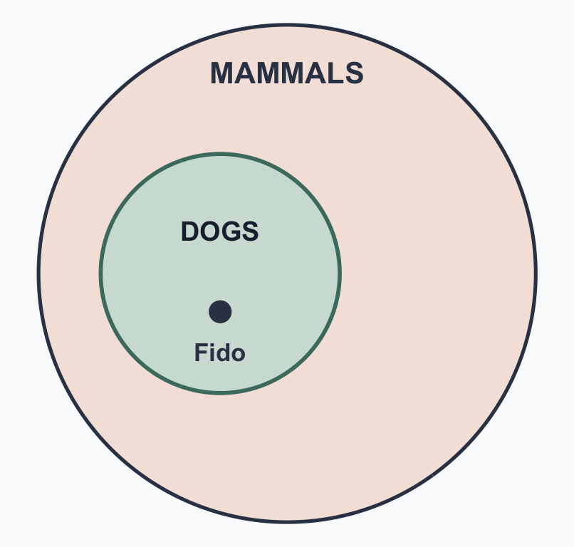

Figure 1

## Modus Tollens

**P1:** If something is a dog, then it is a mammal.  
**P2:** Fido is not a mammal.  
**C:** Fido is not a dog.

**modus tollens**

Shape: **If P, then Q. Not Q. so Not P**

**Valid** — the logic behind *falsification*.

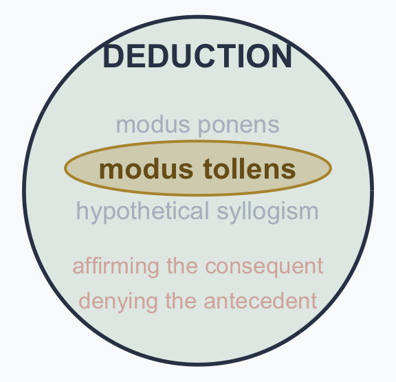

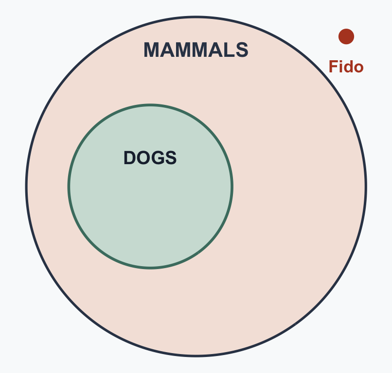

Figure 2

## Hypothetical Syllogism

**P1:** If dog, then mammal.  
**P2:** If mammal, then animal.  
**C:** If dog, then animal.

**hypothetical syllogism**

Shape: **If P, then Q. If Q, then R. so If P, then R**

**Valid** — but every added link is another premise that can fail.

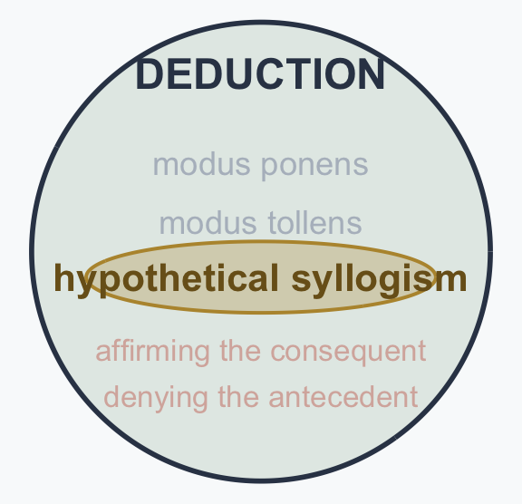

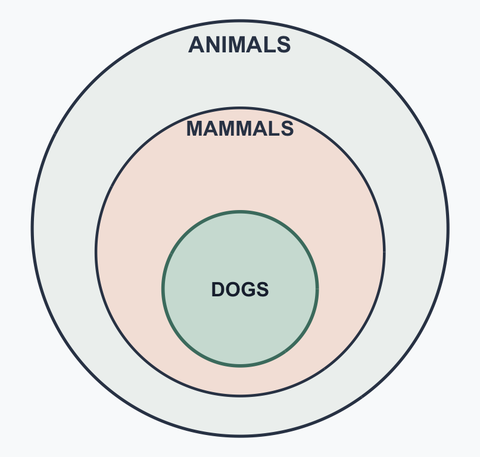

Figure 3

## Look at the Conclusion

Two rules: *“If it rains, the street gets wet.”* · *“If the street is wet, it is slippery.”*

|  | Add this | You conclude |
| --- | --- | --- |
| **Modus ponens** | **It rained.** | The street **is wet.** |
| **Hypothetical syllogism** | *nothing — just the second rule* | **If** it rains, the street is slippery. |

Still an **“if”**? Hypothetical syllogism. A **flat claim**? Modus ponens.

## Affirming the Consequent

**P1:** If something is a dog, then it is a mammal.  
**P2:** Fido is a mammal.  
**C:** Fido is a dog.

But Fido could be a **cat** — a dog is only *one* way to be a mammal.

**affirming the consequent *(invalid)***

Shape: **If P, then Q. Q. so P**

**Trap** — reads the rule **backward.**

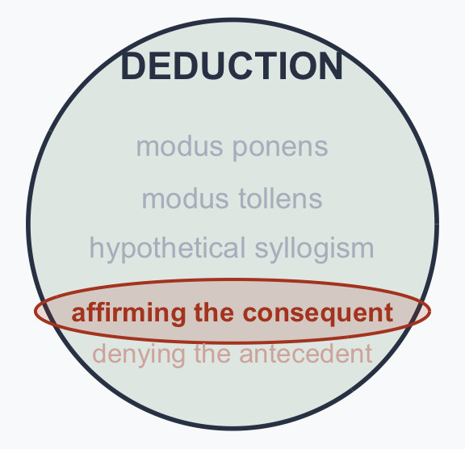

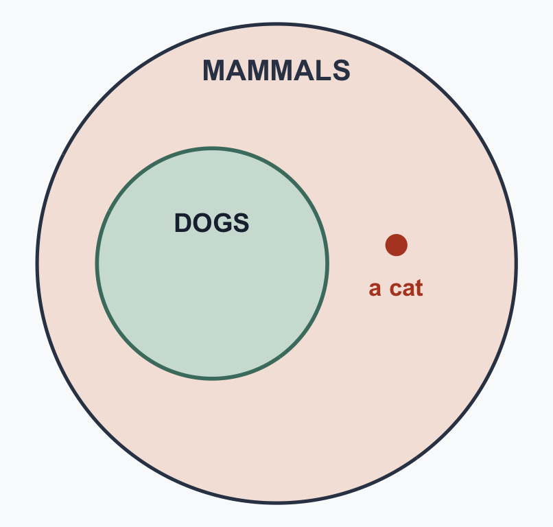

Figure 4

## Denying the Antecedent

**P1:** If something is a dog, then it is a mammal.  
**P2:** Fido is not a dog.  
**C:** Fido is not a mammal.

But Fido could be a **cat** — not a dog, still a mammal.

**denying the antecedent *(invalid)***

Shape: **If P, then Q. Not P. so Not Q**

**Trap** — forgets Q can hold **without P.**

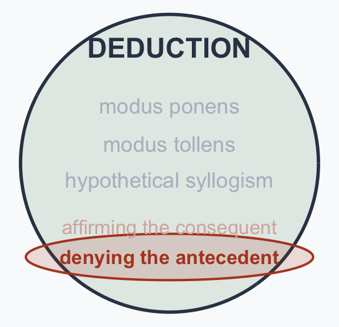

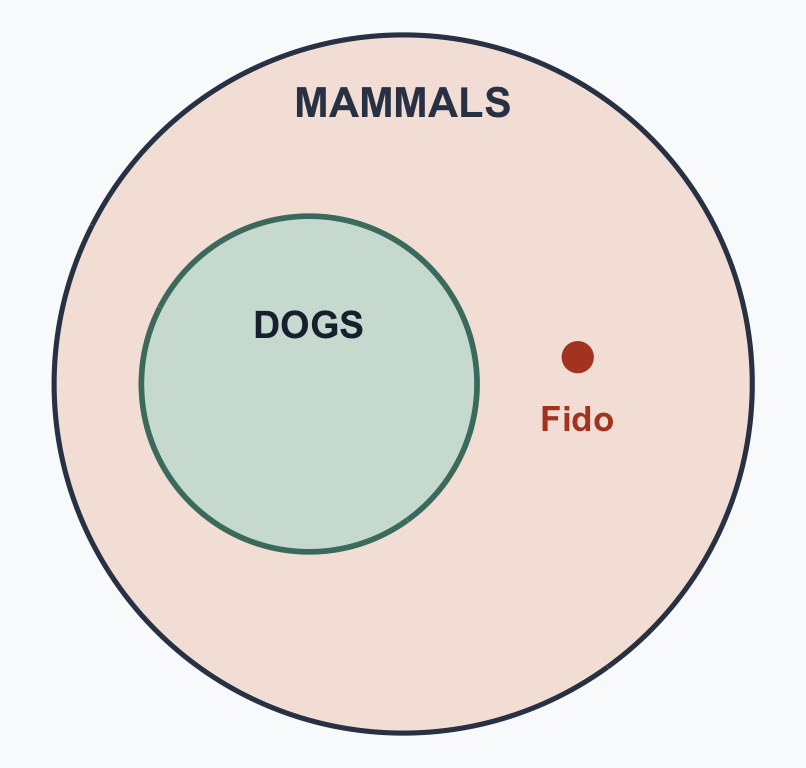

Figure 5

## Tool vs. Trap

Each trap **reverses** its valid counterpart *(all share the rule: **If P, then Q**)*:

| Valid tool | Invalid counterpart | Where it goes wrong |
| --- | --- | --- |
| **Modus ponens** — *P, so Q* | **Affirming the consequent** — *Q, so P* | reads the rule **backward** |
| **Modus tollens** — *Not Q, so Not P* | **Denying the antecedent** — *Not P, so Not Q* | forgets Q can hold **without P** *(the cat)* |

Two questions catch most errors: **(1)** Am I going the *direction* the conditional states? **(2)** Was P the *only* route to Q, or just *one*?

## Necessary vs. Sufficient

> “If it’s a dog, then it’s a mammal.”
- **Dog is sufficient** for mammal — dog guarantees mammal.
- **Mammal is necessary** for dog — no mammal, no dog.
- The traps come from swapping the two.

## The Four Families

| Family | Fallacies |
| --- | --- |
| **Faulty reasoning** | false cause · circular reasoning |
| **Misused sources** | ad hominem · appeal to authority |
| **Distorted claims** | *(Session 10 — not on this exam)* |
| **Emotional appeals** | *(Session 10 — not on this exam)* |

Four fallacies are examinable. The other eight come **after** the midterm.

## The Three-Step Diagnosis

1. **Name** the move.
2. **Quote** the words that commit it.
3. Say what would **decide** the question.

Naming alone is not a refutation — step 3 is where the marks are.

## The Readings

- Sagan, C. (1995). The fine art of baloney detection. In *The demon-haunted world: Science as a candle in the dark* (Ch. 12). Random House.
- Plato. (n.d.). *Euthyphro*.
- Hume, D. (1739). *A treatise of human nature*, Book III, Part I, Section I.
- Hume, D. (1748). *An enquiry concerning human understanding*, Section IV, “Sceptical doubts concerning the operations of the understanding.”
- Vaughn, L., & MacDonald, C. (2019). *The power of critical thinking* (Canadian ed.). Oxford University Press. (Ch. 3, “Making sense of arguments,” pp. 58–106.)
- Kahneman, D. (2011). The characters of the story. In *Thinking, fast and slow* (Ch. 1). Farrar, Straus and Giroux.
- Vaughn, L., & MacDonald, C. (2019). *The power of critical thinking* (Canadian ed.). Oxford University Press. (Ch. 5, “Fallacies and persuaders,” pp. 151–186.)

# Part 2: Practice

*Six drills. Answers on the slide immediately after each.*

## Drill 1 — Label the Claim

Mark each **E**, **C**, or **N**.

**1.** Our Navy is smaller than it was in 1917.

**2.** “Strength” means what a military can do, not how many units it owns.

**3.** We should not weaken the military.

**4.** Turnout was lower this year than last.

## Drill 1 — Answers

|  |  | Why |
| --- | --- | --- |
| **1** | **E** | Count the ships. |
| **2** | **C** | Fixes what the word means. |
| **3** | **N** | A value word — and no amount of data settles it. |
| **4** | **E** | Look up the figures. |

## Part A — On the Exam

**A1.** Costa Rica abolished its army in 1948.  
**A2.** A subsidy is, by definition, a payment from government to a producer.  
**A3.** Voting should be compulsory.

Write only this:

> A1 – E A2 – C A3 – N

One letter each. **No sentences, no reasons.**

## Drill 2 — Family and Verdict

Deductive or inductive? Then: **sound**, **cogent**, or **neither**? *(Assume the stated premises are true.)*

**1.** “All squares have four sides. This figure is a square. So it has four sides.”

**2.** “All dogs are mammals. This animal is a mammal. So it’s a dog.”

**3.** “This mountain pass has closed for snow every winter for thirty years. So it will probably close this winter too.”

**4.** “Two of my friends got sick after eating there. So that restaurant probably has bad hygiene.”

## Drill 2 — Answers

|  | Family | Verdict | Why |
| --- | --- | --- | --- |
| **1** | deductive | **sound** | “Square” forces “four sides”. |
| **2** | deductive | **neither** | Invalid — a cat is a mammal too. |
| **3** | inductive | **cogent** | Thirty winters, same pass, same cause. |
| **4** | inductive | **neither** | Weak — two cases, no base rate. |

A broken link ends it. Nothing rescues an invalid argument.

## Part B — On the Exam

**B1.** “Every treaty the senate ratifies is binding. The senate ratified this treaty. So this treaty is binding.”

Write only this:

> B1 – deductive, sound

**Two things**: the type, then the verdict. Assume the stated premises are true.

## Drill 3 — Name the Shape

Name the pattern, then say **valid** or **trap**.

**1.** “If it’s a dog, then it’s a mammal. Rex is a dog. So Rex is a mammal.”

**2.** “If the video is fake, the detector flags it. The detector flagged it. So the video is fake.”

**3.** “If the vaccine caused the outbreak, the vaccinated would get sick. They didn’t. So it didn’t.”

**4.** “If she deleted the files, she’s guilty. She didn’t delete them. So she’s not guilty.”

**5.** “If it’s a dog, it’s a mammal. If it’s a mammal, it’s an animal. So if it’s a dog, it’s an animal.”

## Drill 3 — Answers

|  | Shape |  |
| --- | --- | --- |
| **1** | Modus ponens | **valid** |
| **2** | Affirming the consequent *(Trap 1)* | **trap** |
| **3** | Modus tollens | **valid** |
| **4** | Denying the antecedent *(Trap 2)* | **trap** |
| **5** | Hypothetical syllogism | **valid** |

Both traps run the arrow **backwards** — or delete a route that was never the only one.

## Part C — On the Exam

**C1.** “If the shipment left on Monday, it arrives Thursday. It did not arrive Thursday. So it did not leave on Monday.”

Write only this:

> C1 – modus tollens, valid

The name, then **valid or trap**. *Tool 2* is accepted for the name.

## Drill 4 — Name the Fallacy

**False cause · circular reasoning · ad hominem · appeal to authority**

**1.** “Brawndo’s got what plants crave — it’s got electrolytes. And electrolytes are what plants crave.”

**2.** “There’s no proof because it’s covered up, and we know it’s covered up because there’s no proof.”

**3.** “The mayor’s figures show the curfew cut crime. But the mayor’s a crook — ignore them.”

**4.** “More doctors smoke this brand than any other, so it must be safe.”

## Drill 4 — Answers

|  |  | Why |
| --- | --- | --- |
| **1** | **circular reasoning** | Every turn renames the claim. Nothing new arrives. |
| **2** | **circular reasoning** | Two claims, each propped up by the other. |
| **3** | **ad hominem** | Attacks the mayor, not the figures. Crooks can still hold correct data. |
| **4** | **appeal to authority** | The survey was real — and brand preference is not a safety finding. |

Circles need not repeat words — **1 and 2 are the same move** in different clothes.

## Part D — On the Exam

**D1.** “This brand must be the best — a famous footballer endorses it.”

Write only this:

> D1 – appeal to authority

The **name only**. No quotation, no explanation — that is Part E’s job.

## Drill 5 — Run the Three Steps

> “Crime fell after the curfew. The curfew works.”
- **Name** the move.
- **Quote** the words.
- Say what would **decide** it.

## Drill 5 — Answers

| Step |  |
| --- | --- |
| **Name** | False cause |
| **Quote** | “Crime fell **after** the curfew. The curfew works.” |
| **Decide** | Was crime already falling before? What happened in comparable cities with no curfew? |

“After” is not “because.” Rule out the rivals, or you have not shown anything.

## Part E — On the Exam

> “Museum attendance rose 30% the year after the café opened. The café is what brought the crowds in.”

Write three separate lines:

> E(a) – false cause  
> E(b) – “The café is what brought the crowds in”  
> E(c) – I would check two things: 1) whether attendance was already rising before the café opened, and 2) whether other museums in the city rose by the same amount that year.

## Drill 6 — Reconstruct

> “Violent video games should be restricted for minors — children who play them behave more aggressively at school.”

Put it in standard form. Find the **hidden premise.**

## Drill 6 — Answers

| P1. | Children who play violent games behave more aggressively at school. *(E)* |
| --- | --- |
| P2. | *(hidden)* Behaving more aggressively is caused by the games, not merely correlated. *(E)* |
| P3. | *(hidden)* We should restrict what makes children more aggressive. *(N)* |
| C. | Violent video games should be restricted for minors. |

The conclusion is a **should.** So at least one premise must be a **should.**

## Part F — On the Exam

> “Street stalls should be inspected like restaurants — after all, they serve food to the public.”

Write the argument out, then the label:

> P1. Street stalls serve food to the public.  
> P2. Anything that serves food to the public should be inspected like a restaurant.  
> C. Street stalls should be inspected like restaurants.  
> Ans: N

P1 is **in** the sentence. P2 is the one nobody said.

## Part G — On the Exam

**G1.** Vaughn & MacDonald, Ch. 5 **G2.** Hume, *Treatise*

(a) why facts alone never settle what ought to be done  
(b) a catalogue of the named ways an argument goes wrong  
(c) how formal logic developed after Aristotle

Write only this:

> G1 – b G2 – a

One letter each. **One option is always left over** — so the last answer cannot be had by elimination.

## Conclusion

- **Practise, don’t re-read.** Redo the exercises with the answers covered.
- **Say the four steps** out loud, in order, from memory. *family · link · premises · verdict*
- **Rehearse the four fallacies** — name, then what would decide it. *false cause · circular · ad hominem · appeal to authority*
- **One line per reading** — what it was about, nothing more.

## Encuesta

[figure not shown]